# Cours R - Projet Final

Amine Aliane[^1]

Meriam Hammouda[^2]

Imed Eddine Boussouf[^3]

Khaoula Elmoutamid[^4]

Lina Saidane[^5]

Esteban Gobert[^6]

30 avril 2020

## Présentation des données

Nous allons nous intéresser au jeu de données : train_users

Data Frame Summary

real_train_users_NA

**Dimensions**: 68241 x 15  
**Duplicates**: 0

| **Variable** | **Stats / Values** | **Freqs (% of Valid)** | **Graph** | **Valid** | **Missing** |
| --- | --- | --- | --- | --- | --- |
| date_account_created [Date] | min : 2010-01-01 med : 2013-05-17 max : 2014-06-28 range : 4y 5m 27d | 1534 distinct values |  | 68241 (100%) | 0 (0%) |
| timestamp_first_active [numeric] | Mean (sd) : 20127453462819.6 (9252231188.9) min < med < max: 20090609231247 < 20130516204111 < 20140331235546 IQR (CV) : 10296950809 (0) | 68241 distinct values |  | 68241 (100%) | 0 (0%) |
| date_first_booking [Date] | min : 2010-01-02 med : 2013-06-21 max : 2015-06-11 range : 5y 5m 9d | 1874 distinct values |  | 68241 (100%) | 0 (0%) |
| gender [character] | 1. FEMALE 2. MALE | 24936 ( 54.0% ) 21275 ( 46.0% ) |  | 46211 (67.72%) | 22030 (32.28%) |
| age [numeric] | Mean (sd) : 36.3 (11) min < med < max: 18 < 33 < 89 IQR (CV) : 12 (0.3) | 72 distinct values |  | 51383 (75.3%) | 16858 (24.7%) |
| signup_method [character] | 1. basic 2. facebook | 49458 ( 72.5% ) 18783 ( 27.5% ) |  | 68241 (100%) | 0 (0%) |
| signup_flow [numeric] | Mean (sd) : 2 (5.7) min < med < max: 0 < 0 < 25 IQR (CV) : 0 (2.8) | 16 distinct values |  | 68241 (100%) | 0 (0%) |
| language [character] | 1. en | 68241 ( 100.0% ) |  | 68241 (100%) | 0 (0%) |
| affiliate_channel [character] | 1. api 2. direct 3. other 4. sem-brand 5. sem-non-brand 6. seo | 2563 ( 3.8% ) 45799 ( 67.1% ) 3994 ( 5.9% ) 7073 ( 10.4% ) 5767 ( 8.5% ) 3045 ( 4.5% ) |  | 68241 (100%) | 0 (0%) |
| affiliate_provider [character] | 1. direct 2. google 3. other | 45642 ( 66.9% ) 14745 ( 21.6% ) 7854 ( 11.5% ) |  | 68241 (100%) | 0 (0%) |
| first_affiliate_tracked [character] | 1. linked 2. omg 3. tracked-other 4. untracked | 15741 ( 23.7% ) 11373 ( 17.1% ) 2427 ( 3.6% ) 36963 ( 55.6% ) |  | 66504 (97.45%) | 1737 (2.55%) |
| signup_app [character] | 1. Android 2. iOS 3. Moweb 4. Web | 701 ( 1.0% ) 3437 ( 5.0% ) 1485 ( 2.2% ) 62618 ( 91.8% ) |  | 68241 (100%) | 0 (0%) |
| first_device_type [character] | 1. iPad 2. iPhone 3. Mac Desktop 4. Other/Unknown 5. Windows Desktop | 4068 ( 6.0% ) 3971 ( 5.8% ) 33726 ( 49.4% ) 3215 ( 4.7% ) 23261 ( 34.1% ) |  | 68241 (100%) | 0 (0%) |
| first_browser [character] | 1. Chrome 2. Firefox 3. IE 4. Mobile Safari 5. Safari | 22962 ( 36.5% ) 12889 ( 20.5% ) 6130 ( 9.7% ) 5332 ( 8.5% ) 15616 ( 24.8% ) |  | 62929 (92.22%) | 5312 (7.78%) |
| country_destination [character] | 1. AU 2. CA 3. DE 4. ES 5. FR 6. GB 7. IT 8. NL 9. other 10. PT 11. US | 440 ( 0.6% ) 1086 ( 1.6% ) 828 ( 1.2% ) 1718 ( 2.5% ) 3933 ( 5.8% ) 1815 ( 2.7% ) 2137 ( 3.1% ) 555 ( 0.8% ) 7581 ( 11.1% ) 152 ( 0.2% ) 47996 ( 70.3% ) |  | 68241 (100%) | 0 (0%) |

Generated by summarytools 0.9.6 ([R](https://www.r-project.org/) version 3.6.3)  
2020-05-02

Avec cette description on peut observer que nous avons des variables aberrantes, extrèmes et manquantes, il faut donc les traiter.

- abbberantes :
  - age : On considère comme aberrantes les valeurs pour âge < 18 et âge >= 90
- extrêmes :
  - first_browser : Garder les modalités chrome, firefox, IE, Safari et mobile Safari.
  - affiliate_provider : On garde les modalités “direct”, “google” et on regroupe tout le reste dans la modalité “others”.
  - gender : Suppression des lignes “OTHER” (0,14%)
  - first_device_type : Regroupement de “Android Phone”, “Android Tablet” et “Desktop (Other)” en “Other/Unknown”.
  - language : On supprime les lignes où il y a - de 1% d’effectif, il ne reste plus qu’une seule modalité possible la colonne devient inutile.
  - affiliate_channel : On regroupe les modalité qui ont - de 1000 entités en “other”.
  - first_affiliate_tracked : On regroupe les modalité qui ont - de 1000 entités en “tracked-other”.
- manquantes :
  - gender : Distribuer le genre sur les NAs en fonction de la proportion de MALE et FEMALE.
  - age, first_affiliate_tracked et first_browser : Distribution par LOCF pour ne pas briser la distribution originale.

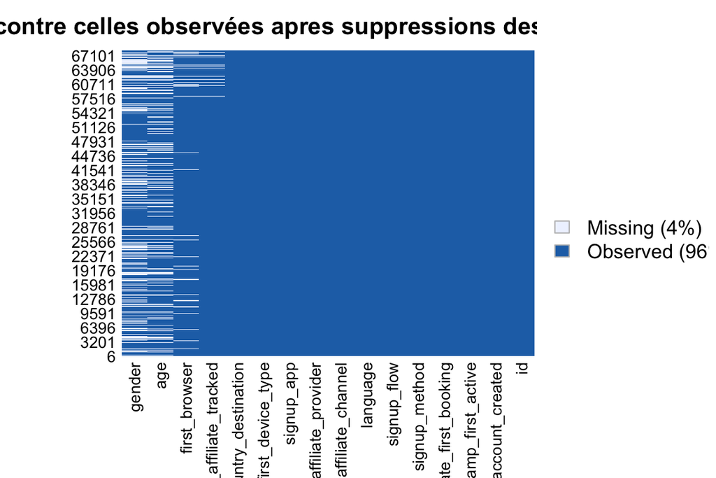

|  | Nombre de valeur manquante |
| --- | --- |
| id | 0 |
| date_account_created | 0 |
| timestamp_first_active | 0 |
| date_first_booking | 0 |
| gender | 22030 |
| age | 16858 |
| signup_method | 0 |
| signup_flow | 0 |
| language | 0 |
| affiliate_channel | 0 |
| affiliate_provider | 0 |
| first_affiliate_tracked | 1737 |
| signup_app | 0 |
| first_device_type | 0 |
| first_browser | 5312 |
| country_destination | 0 |

## Statistiques descriptives du jeu de données train_users

Data Frame Summary

real_train_users

**Dimensions**: 68241 x 16  
**Duplicates**: 0

| **Variable** | **Stats / Values** | **Freqs (% of Valid)** | **Graph** | **Valid** |
| --- | --- | --- | --- | --- |
| date_account_created [Date] | min : 2010-01-01 med : 2013-05-17 max : 2014-06-28 range : 4y 5m 27d | 1534 distinct values |  | 68241 (100%) |
| timestamp_first_active [numeric] | Mean (sd) : 20127453462819.6 (9252231188.9) min < med < max: 20090609231247 < 20130516204111 < 20140331235546 IQR (CV) : 10296950809 (0) | 68241 distinct values |  | 68241 (100%) |
| date_first_booking [Date] | min : 2010-01-02 med : 2013-06-21 max : 2015-06-11 range : 5y 5m 9d | 1874 distinct values |  | 68241 (100%) |
| gender [character] | 1. FEMALE 2. MALE | 36695 ( 53.8% ) 31546 ( 46.2% ) |  | 68241 (100%) |
| age [numeric] | Mean (sd) : 36.3 (11) min < med < max: 18 < 33 < 89 IQR (CV) : 12 (0.3) | 72 distinct values |  | 68241 (100%) |
| signup_method [character] | 1. basic 2. facebook | 49458 ( 72.5% ) 18783 ( 27.5% ) |  | 68241 (100%) |
| signup_flow [numeric] | Mean (sd) : 2 (5.7) min < med < max: 0 < 0 < 25 IQR (CV) : 0 (2.8) | 16 distinct values |  | 68241 (100%) |
| language [character] | 1. en | 68241 ( 100.0% ) |  | 68241 (100%) |
| affiliate_channel [character] | 1. api 2. direct 3. other 4. sem-brand 5. sem-non-brand 6. seo | 2563 ( 3.8% ) 45799 ( 67.1% ) 3994 ( 5.9% ) 7073 ( 10.4% ) 5767 ( 8.5% ) 3045 ( 4.5% ) |  | 68241 (100%) |
| affiliate_provider [character] | 1. direct 2. google 3. other | 45642 ( 66.9% ) 14745 ( 21.6% ) 7854 ( 11.5% ) |  | 68241 (100%) |
| first_affiliate_tracked [character] | 1. linked 2. omg 3. tracked-other 4. untracked | 16118 ( 23.6% ) 11568 ( 17.0% ) 2498 ( 3.7% ) 38057 ( 55.8% ) |  | 68241 (100%) |
| signup_app [character] | 1. Android 2. iOS 3. Moweb 4. Web | 701 ( 1.0% ) 3437 ( 5.0% ) 1485 ( 2.2% ) 62618 ( 91.8% ) |  | 68241 (100%) |
| first_device_type [character] | 1. iPad 2. iPhone 3. Mac Desktop 4. Other/Unknown 5. Windows Desktop | 4068 ( 6.0% ) 3971 ( 5.8% ) 33726 ( 49.4% ) 3215 ( 4.7% ) 23261 ( 34.1% ) |  | 68241 (100%) |
| first_browser [character] | 1. Chrome 2. Firefox 3. IE 4. Mobile Safari 5. Safari | 24924 ( 36.5% ) 14000 ( 20.5% ) 6610 ( 9.7% ) 5793 ( 8.5% ) 16914 ( 24.8% ) |  | 68241 (100%) |
| country_destination [character] | 1. AU 2. CA 3. DE 4. ES 5. FR 6. GB 7. IT 8. NL 9. other 10. PT 11. US | 440 ( 0.6% ) 1086 ( 1.6% ) 828 ( 1.2% ) 1718 ( 2.5% ) 3933 ( 5.8% ) 1815 ( 2.7% ) 2137 ( 3.1% ) 555 ( 0.8% ) 7581 ( 11.1% ) 152 ( 0.2% ) 47996 ( 70.3% ) |  | 68241 (100%) |
| age_tranche [factor] | 1. 15-19 2. 20-24 3. 25-29 4. 30-34 5. 35-39 6. 40-44 7. 45-49 8. 50-54 9. 55-59 10. 60-64 [ 5 others ] | 997 ( 1.5% ) 6008 ( 8.8% ) 16627 ( 24.4% ) 16696 ( 24.5% ) 9988 ( 14.6% ) 6015 ( 8.8% ) 3853 ( 5.6% ) 2807 ( 4.1% ) 2110 ( 3.1% ) 1608 ( 2.4% ) 1532 ( 2.2% ) |  | 68241 (100%) |

Generated by summarytools 0.9.6 ([R](https://www.r-project.org/) version 3.6.3)  
2020-05-02

### Variables quantitatives

Bien qu’ayant déjà une description complète dans le tableau précédent, nous pouvons observer les variables quantitatives d’une autre manière.

On étudie la densité des variables quantitatives :

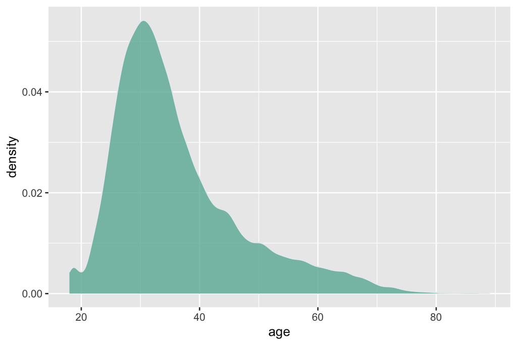

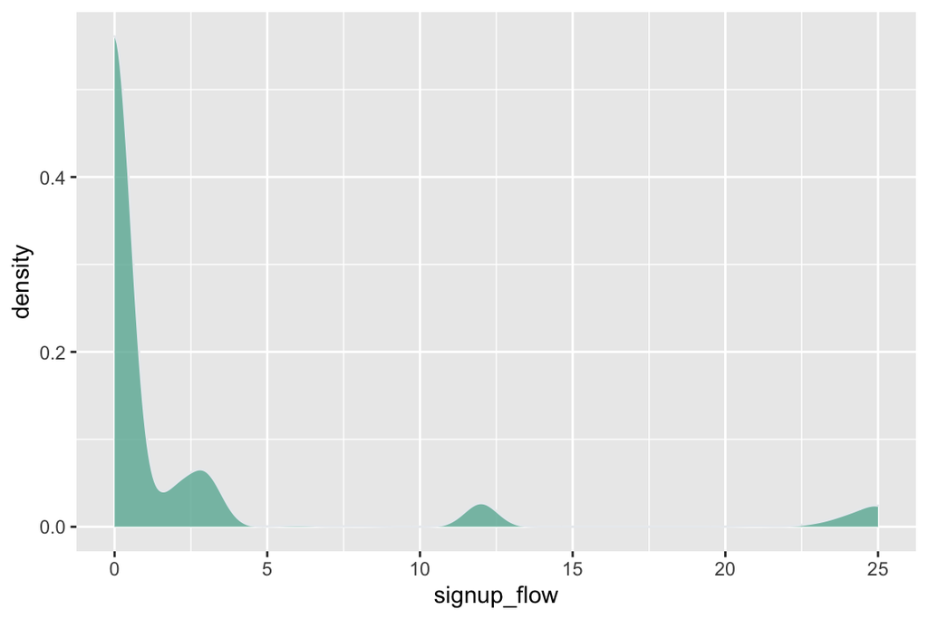

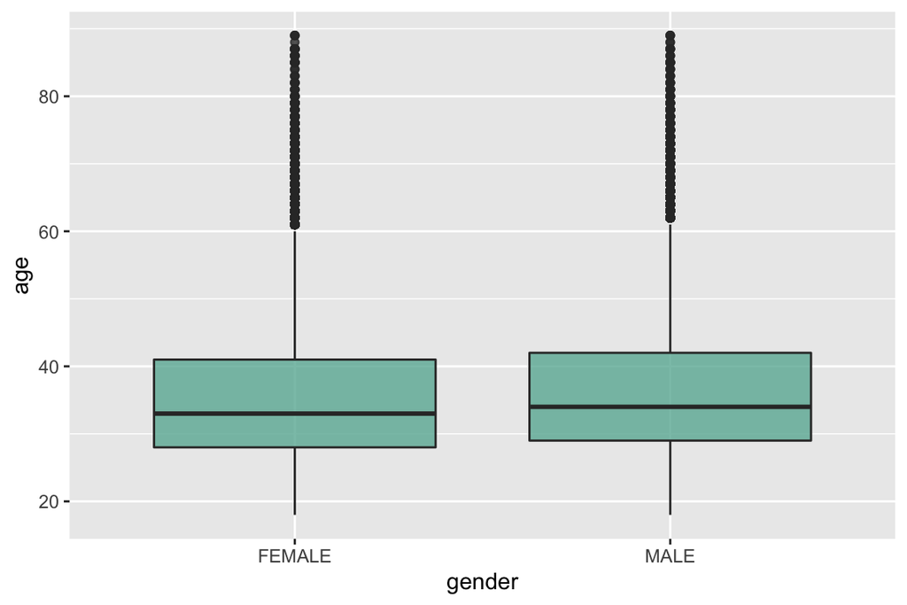

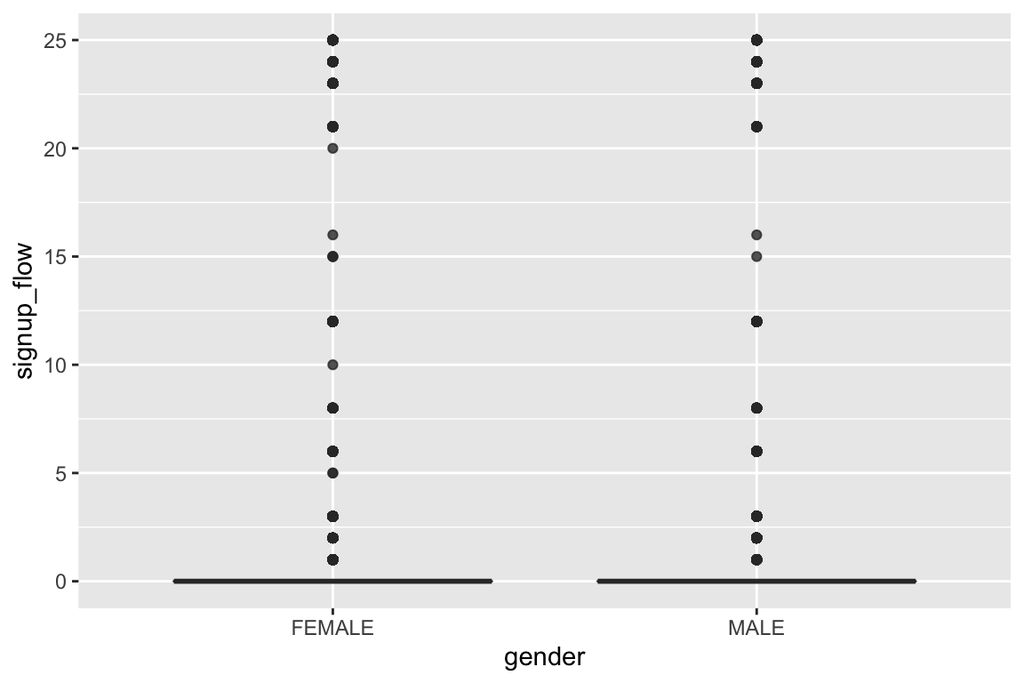

On observe la corrélation entre les variables age et signup_flow :

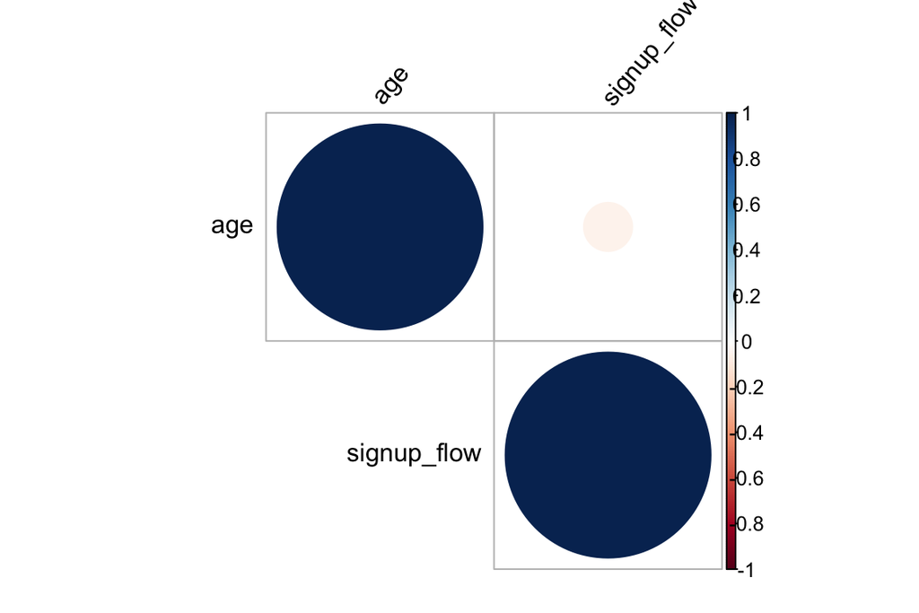

Les corrélations positives sont affichées en bleu et les corrélations négatives en rouge.  
L’intensité de la couleur et la taille des cercles sont proportionnelles aux coefficients de corrélation.  
A droite du corrélogramme, la légende de couleurs montre les coefficients de corrélation et les couleurs correspondantes.

On peut voir que les 2 variables ne sont pas vraiment corrélés.

Test de Student par âge / gender :

```
##
##  Welch Two Sample t-test
##
## data:  real_train_users$age by real_train_users$gender
## t = -6.8053, df = 67073, p-value = 1.017e-11
## alternative hypothesis: true difference in means is not equal to 0
## 95 percent confidence interval:
##  -0.7366219 -0.4071926
## sample estimates:
## mean in group FEMALE   mean in group MALE
##             36.04494             36.61685
```

### Variables qualitatives

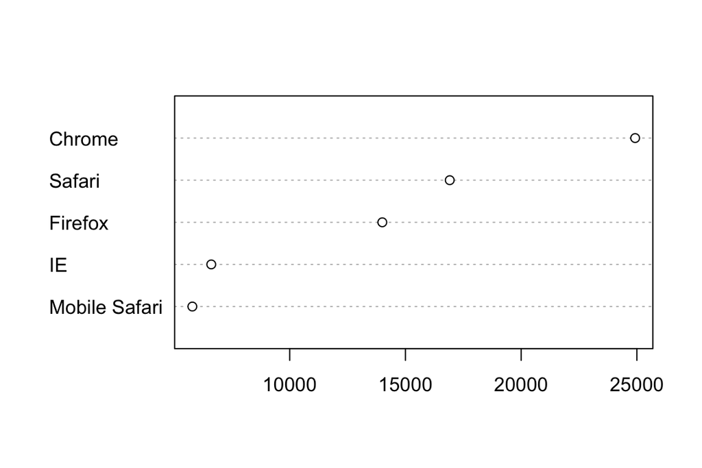

```
##
##         FEMALE  MALE
##   AU       243   197
##   CA       553   533
##   DE       403   425
##   ES       932   786
##   FR      2285  1648
##   GB      1017   798
##   IT      1285   852
##   NL       283   272
##   other   3893  3688
##   PT        84    68
##   US     25717 22279
```

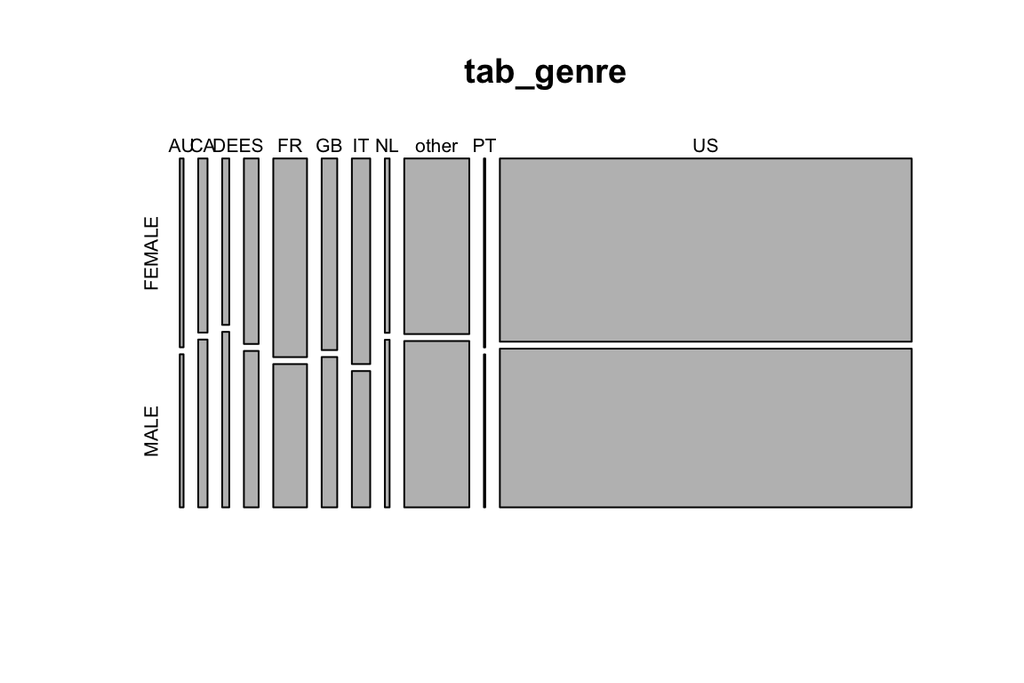

```
##
##  Pearson's Chi-squared test
##
## data:  tab_genre
## X-squared = 101.28, df = 10, p-value < 2.2e-16
```

```
##
##         FEMALE  MALE
##   AU      0.42 -0.45
##   CA     -1.28  1.38
##   DE     -2.00  2.16
##   ES      0.27 -0.29
##   FR      3.70 -3.99
##   GB      1.31 -1.42
##   IT      4.01 -4.32
##   NL     -0.89  0.96
##   other  -2.87  3.10
##   PT      0.25 -0.27
##   US     -0.57  0.62
```

## Statistiques descriptives du jeu de données sessions

On s’intéresse maintenant au jeu de données sessions, nous allons calculer des indicateurs

Data Frame Summary

user_sessions

**Dimensions**: 74610 x 10  
**Duplicates**: 1706

| **Variable** | **Stats / Values** | **Freqs (% of Valid)** | **Graph** | **Valid** |
| --- | --- | --- | --- | --- |
| NbActions [integer] | Mean (sd) : 12.9 (8.2) min < med < max: 1 < 11 < 72 IQR (CV) : 8 (0.6) | 65 distinct values |  | 74610 (100%) |
| NbActions_ActionsTypes [integer] | Mean (sd) : 13.9 (8.8) min < med < max: 1 < 12 < 80 IQR (CV) : 10 (0.6) | 69 distinct values |  | 74610 (100%) |
| NbActions_ActionsTypes_ActionDetails [integer] | Mean (sd) : 14.8 (9.7) min < med < max: 1 < 13 < 89 IQR (CV) : 11 (0.7) | 78 distinct values |  | 74610 (100%) |
| NbDevices [integer] | Mean (sd) : 1.3 (0.6) min < med < max: 1 < 1 < 6 IQR (CV) : 1 (0.4) | 1 : 54394 ( 72.9% ) 2 : 17438 ( 23.4% ) 3 : 2440 ( 3.3% ) 4 : 302 ( 0.4% ) 5 : 33 ( 0.0% ) 6 : 3 ( 0.0% ) |  | 74610 (100%) |
| dureeTotal [numeric] | Mean (sd) : 1512822.5 (1915348.3) min < med < max: 0 < 870696 < 38221363 IQR (CV) : 1787003 (1.3) | 70875 distinct values |  | 74610 (100%) |
| mostFreqAction [character] | 1. show 2. search_results 3. index 4. update 5. create 6. active 7. dashboard 8. requested 9. personalize 10. search [ 141 others ] | 29343 ( 39.6% ) 6198 ( 8.4% ) 3625 ( 4.9% ) 3391 ( 4.6% ) 3152 ( 4.3% ) 3124 ( 4.2% ) 2653 ( 3.6% ) 2354 ( 3.2% ) 2061 ( 2.8% ) 1994 ( 2.7% ) 16137 ( 21.8% ) |  | 74032 (99.23%) |
| mostFreqAction_ActionType [character] | 1. show view 2. search_results click 3. personalize data 4. index view 5. ajax_refresh_subtotal cli 6. active NA 7. update submit 8. create submit 9. dashboard view 10. search click [ 163 others ] | 15333 ( 20.6% ) 7644 ( 10.2% ) 6596 ( 8.8% ) 4840 ( 6.5% ) 3641 ( 4.9% ) 3584 ( 4.8% ) 3439 ( 4.6% ) 2954 ( 4.0% ) 2953 ( 4.0% ) 2260 ( 3.0% ) 21366 ( 28.6% ) |  | 74610 (100%) |
| mostFreqAction_ActionType_ActionDetail [character] | 1. search_results click view 2. personalize data wishlist 3. show view p3 4. show view user_profile 5. active NA NA 6. ajax_refresh_subtotal cli 7. index view view_search_re 8. dashboard view dashboar… | 8021 ( 10.8% ) 7477 ( 10.0% ) 6517 ( 8.7% ) 4581 ( 6.1% ) 4223 ( 5.7% ) 3986 ( 5.3% ) 3365 ( 4.5% ) 3216 ( 4.3% ) 3132 ( 4.2% ) 2985 ( 4.0% ) 27107 ( 36.3% ) |  | 74610 (100%) |
| mostFreqDeviceType [character] | 1. Mac Desktop 2. Windows Desktop 3. iPhone 4. iPad 5. Android App Unknown Phone 6. Android Phone 7. Tablet 8. Linux Desktop 9. Chromebook 10. iPodtouch [ 2 others ] | 27656 ( 38.9% ) 23036 ( 32.4% ) 9805 ( 13.8% ) 5183 ( 7.3% ) 2588 ( 3.6% ) 1674 ( 2.4% ) 655 ( 0.9% ) 268 ( 0.4% ) 224 ( 0.3% ) 36 ( 0.1% ) 14 ( 0.0% ) |  | 71139 (95.35%) |
| dureeMedian [numeric] | Mean (sd) : 7173.9 (49679.4) min < med < max: 0 < 1269 < 1765056 IQR (CV) : 2003.5 (6.9) | 16972 distinct values |  | 73405 (98.38%) |

Generated by summarytools 0.9.6 ([R](https://www.r-project.org/) version 3.6.3)  
2020-05-02

## Statistiques descriptives du jeu de données train_dataset

Nous allons opérer une jointure entre l’agrégation des sessions (user_sessions) et le dataset d’entrainement (train_users).  
Ensuite nous allons faire une jointure avec les dataset subsidiaires countries et age_gender_bkts.

Pour que la jointure s’opère avec le dataset age_gender_bkts il faut effectuer quelques changements :

- créer une nouvelle variable tranche_age pour matcher avec la colonne age_bucket
- mettre en lettres capitales les modalités de la colonne gender (age_gender_bkts)

Issu de la jointure entre les dataset train_users, user_sessions, age_gender_bkts et countries : le jeu de données train_dataset nous permet de décrire les variables d’une autre manière

Data Frame Summary

train_dataset

**Dimensions**: 11543 x 34  
**Duplicates**: 0

| **Variable** | **Stats / Values** | **Freqs (% of Valid)** | **Graph** | **Valid** |
| --- | --- | --- | --- | --- |
| date_account_created [Date] | min : 2014-01-01 med : 2014-02-17 max : 2014-03-31 range : 2m 30d | 90 distinct values |  | 11543 (100%) |
| timestamp_first_active [numeric] | Mean (sd) : 20140219727487.5 (83485101.5) min < med < max: 20140101000936 < 20140217054001 < 20140331235546 IQR (CV) : 187012254 (0) | 11543 distinct values |  | 11543 (100%) |
| date_first_booking [Date] | min : 2014-01-01 med : 2014-03-07 max : 2015-03-27 range : 1y 2m 26d | 437 distinct values |  | 11543 (100%) |
| gender [character] | 1. FEMALE 2. MALE | 6185 ( 53.6% ) 5358 ( 46.4% ) |  | 11543 (100%) |
| age [numeric] | Mean (sd) : 35.1 (11.3) min < med < max: 18 < 32 < 86 IQR (CV) : 13 (0.3) | 68 distinct values |  | 11543 (100%) |
| signup_method [character] | 1. basic 2. facebook | 8835 ( 76.5% ) 2708 ( 23.5% ) |  | 11543 (100%) |
| signup_flow [numeric] | Mean (sd) : 2.4 (6.6) min < med < max: 0 < 0 < 25 IQR (CV) : 0 (2.8) | 0 : 10052 ( 87.1% ) 8 : 17 ( 0.1% ) 12 : 688 ( 6.0% ) 23 : 139 ( 1.2% ) 24 : 196 ( 1.7% ) 25 : 451 ( 3.9% ) |  | 11543 (100%) |
| language [character] | 1. en | 11543 ( 100.0% ) |  | 11543 (100%) |
| affiliate_channel [character] | 1. api 2. direct 3. other 4. sem-brand 5. sem-non-brand 6. seo | 688 ( 6.0% ) 7217 ( 62.5% ) 379 ( 3.3% ) 1736 ( 15.0% ) 782 ( 6.8% ) 741 ( 6.4% ) |  | 11543 (100%) |
| affiliate_provider [character] | 1. direct 2. google 3. other | 7217 ( 62.5% ) 3135 ( 27.2% ) 1191 ( 10.3% ) |  | 11543 (100%) |
| first_affiliate_tracked [character] | 1. linked 2. omg 3. tracked-other 4. untracked | 2509 ( 21.7% ) 2533 ( 21.9% ) 374 ( 3.2% ) 6127 ( 53.1% ) |  | 11543 (100%) |
| signup_app [character] | 1. Android 2. iOS 3. Moweb 4. Web | 323 ( 2.8% ) 880 ( 7.6% ) 266 ( 2.3% ) 10074 ( 87.3% ) |  | 11543 (100%) |
| first_device_type [character] | 1. iPad 2. iPhone 3. Mac Desktop 4. Other/Unknown 5. Windows Desktop | 764 ( 6.6% ) 661 ( 5.7% ) 5613 ( 48.6% ) 516 ( 4.5% ) 3989 ( 34.6% ) |  | 11543 (100%) |
| first_browser [character] | 1. Chrome 2. Firefox 3. IE 4. Mobile Safari 5. Safari | 4633 ( 40.1% ) 1975 ( 17.1% ) 1003 ( 8.7% ) 1169 ( 10.1% ) 2763 ( 23.9% ) |  | 11543 (100%) |
| country_destination [character] | 1. AU 2. CA 3. DE 4. ES 5. FR 6. GB 7. IT 8. NL 9. other 10. PT 11. US | 68 ( 0.6% ) 136 ( 1.2% ) 83 ( 0.7% ) 265 ( 2.3% ) 544 ( 4.7% ) 278 ( 2.4% ) 380 ( 3.3% ) 77 ( 0.7% ) 1524 ( 13.2% ) 28 ( 0.2% ) 8160 ( 70.7% ) |  | 11543 (100%) |
| age_tranche [character] | 1. 25-29 2. 30-34 3. 20-24 4. 35-39 5. 40-44 6. 45-49 7. 50-54 8. 55-59 9. 60-64 10. 15-19 [ 5 others ] | 3099 ( 26.8% ) 2523 ( 21.9% ) 1684 ( 14.6% ) 1353 ( 11.7% ) 789 ( 6.8% ) 573 ( 5.0% ) 460 ( 4.0% ) 353 ( 3.1% ) 284 ( 2.5% ) 182 ( 1.6% ) 243 ( 2.1% ) |  | 11543 (100%) |
| NbActions [integer] | Mean (sd) : 14.4 (8.9) min < med < max: 1 < 13 < 59 IQR (CV) : 11 (0.6) | 57 distinct values |  | 11543 (100%) |
| NbActions_ActionsTypes [integer] | Mean (sd) : 15.5 (9.7) min < med < max: 1 < 14 < 67 IQR (CV) : 11 (0.6) | 63 distinct values |  | 11543 (100%) |
| NbActions_ActionsTypes_ActionDetails [integer] | Mean (sd) : 16.4 (10.5) min < med < max: 1 < 15 < 72 IQR (CV) : 13 (0.6) | 69 distinct values |  | 11543 (100%) |
| NbDevices [integer] | Mean (sd) : 1.3 (0.5) min < med < max: 1 < 1 < 4 IQR (CV) : 0 (0.4) | 1 : 8690 ( 75.3% ) 2 : 2548 ( 22.1% ) 3 : 283 ( 2.5% ) 4 : 22 ( 0.2% ) |  | 11543 (100%) |
| dureeTotal [numeric] | Mean (sd) : 1752597.6 (2016358.7) min < med < max: 0 < 1137112 < 31393292 IQR (CV) : 1975577 (1.2) | 11226 distinct values |  | 11543 (100%) |
| mostFreqAction [character] | 1. show 2. search_results 3. requested 4. create 5. personalize 6. ajax_refresh_subtotal 7. lookup 8. active 9. ask_question 10. index [ 73 others ] | 3590 ( 31.6% ) 1227 ( 10.8% ) 861 ( 7.6% ) 689 ( 6.1% ) 577 ( 5.1% ) 445 ( 3.9% ) 431 ( 3.8% ) 409 ( 3.6% ) 374 ( 3.3% ) 333 ( 2.9% ) 2442 ( 21.5% ) |  | 11378 (98.57%) |
| mostFreqAction_ActionType [character] | 1. personalize data 2. search_results click 3. ajax_refresh_subtotal cli 4. create submit 5. show view 6. requested view 7. lookup NA 8. active NA 9. ask_question submit 10. edit view [ 95 others ] | 1894 ( 16.4% ) 1509 ( 13.1% ) 1087 ( 9.4% ) 732 ( 6.3% ) 713 ( 6.2% ) 690 ( 6.0% ) 583 ( 5.1% ) 444 ( 3.8% ) 380 ( 3.3% ) 335 ( 2.9% ) 3176 ( 27.5% ) |  | 11543 (100%) |
| mostFreqAction_ActionType_ActionDetail [character] | 1. personalize data wishlist 2. search_results click view 3. ajax_refresh_subtotal cli 4. requested view p5 5. lookup NA NA 6. active NA NA 7. ask_question submit conta 8. edit view edit_profile 9. au… | 2045 ( 17.7% ) 1532 ( 13.3% ) 1147 ( 9.9% ) 766 ( 6.6% ) 604 ( 5.2% ) 499 ( 4.3% ) 386 ( 3.3% ) 374 ( 3.2% ) 254 ( 2.2% ) 224 ( 1.9% ) 3712 ( 32.2% ) |  | 11543 (100%) |
| mostFreqDeviceType [character] | 1. Android App Unknown Phone 2. Android Phone 3. Chromebook 4. iPad 5. iPhone 6. iPodtouch 7. Linux Desktop 8. Mac Desktop 9. Tablet 10. Windows Desktop | 353 ( 3.2% ) 8 ( 0.1% ) 37 ( 0.3% ) 726 ( 6.6% ) 569 ( 5.2% ) 1 ( 0.0% ) 35 ( 0.3% ) 5398 ( 49.2% ) 71 ( 0.7% ) 3783 ( 34.4% ) |  | 10981 (95.13%) |
| dureeMedian [numeric] | Mean (sd) : 12013.5 (64610.8) min < med < max: 0 < 1954.2 < 1428337 IQR (CV) : 3873.1 (5.4) | 7156 distinct values |  | 11350 (98.33%) |
| lat_destination [numeric] | Mean (sd) : 38.4 (7.2) min < med < max: -26.9 < 37 < 62.4 IQR (CV) : 0 (0.2) | -26.85! : 68 ( 0.7% ) 36.97! : 8160 ( 81.5% ) 39.55! : 28 ( 0.3% ) 39.90! : 265 ( 2.6% ) 41.87! : 380 ( 3.8% ) 46.23! : 544 ( 5.4% ) 51.17! : 83 ( 0.8% ) 52.13! : 77 ( 0.8% ) 54.63! : 278 ( 2.8% ) 62.… |  | 10019 (86.8%) |
| lng_destination [numeric] | Mean (sd) : -77.9 (40.8) min < med < max: -96.8 < -95.8 < 133.3 IQR (CV) : 0 (-0.5) | -96.82! : 136 ( 1.4% ) -95.84! : 8160 ( 81.5% ) -7.84! : 28 ( 0.3% ) -3.43! : 278 ( 2.8% ) -2.49! : 265 ( 2.6% ) 2.21! : 544 ( 5.4% ) 5.30! : 77 ( 0.8% ) 10.45! : 83 ( 0.8% ) 12.56! : 380 ( 3.8% ) 133… |  | 10019 (86.8%) |
| distance_km [numeric] | Mean (sd) : 1426.1 (3113.6) min < med < max: 0 < 0 < 15297.7 IQR (CV) : 0 (2.2) | 0.00 : 8160 ( 81.5% ) 2828.13! : 136 ( 1.4% ) 6883.66! : 278 ( 2.8% ) 7355.25! : 28 ( 0.3% ) 7524.32! : 77 ( 0.8% ) 7682.94! : 544 ( 5.4% ) 7730.72! : 265 ( 2.6% ) 7879.57! : 83 ( 0.8% ) 8636.63! : 38… |  | 10019 (86.8%) |
| destination_km2 [numeric] | Mean (sd) : 8261481.2 (3491561.4) min < med < max: 41543 < 9826675 < 9984670 IQR (CV) : 0 (0.4) | 41543 : 77 ( 0.8% ) 92090 : 28 ( 0.3% ) 243610 : 278 ( 2.8% ) 301340 : 380 ( 3.8% ) 357022 : 83 ( 0.8% ) 505370 : 265 ( 2.6% ) 643801 : 544 ( 5.4% ) 7741220 : 68 ( 0.7% ) 9826675 : 8160 ( 81.5% ) 9984… |  | 10019 (86.8%) |
| destination_language [character] | 1. deu 2. eng 3. fra 4. ita 5. nld 6. por 7. spa | 83 ( 0.8% ) 8642 ( 86.3% ) 544 ( 5.4% ) 380 ( 3.8% ) 77 ( 0.8% ) 28 ( 0.3% ) 265 ( 2.6% ) |  | 10019 (86.8%) |
| language_levenshtein_distance [numeric] | Mean (sd) : 12.2 (30.7) min < med < max: 0 < 0 < 95.5 IQR (CV) : 0 (2.5) | 0.00 : 8642 ( 86.3% ) 63.22 : 77 ( 0.8% ) 72.61 : 83 ( 0.8% ) 89.40 : 380 ( 3.8% ) 92.06 : 544 ( 5.4% ) 92.25 : 265 ( 2.6% ) 95.45 : 28 ( 0.3% ) |  | 10019 (86.8%) |
| population_in_thousands [numeric] | Mean (sd) : 9148.5 (3591.3) min < med < max: 275 < 10863 < 11601 IQR (CV) : 751.5 (0.4) | 209 distinct values |  | 10019 (86.8%) |
| year [numeric] | 1 distinct value | 2015 : 10019 ( 100.0% ) |  | 10019 (86.8%) |

Generated by summarytools 0.9.6 ([R](https://www.r-project.org/) version 3.6.3)  
2020-05-02

### Variables Quantitatives

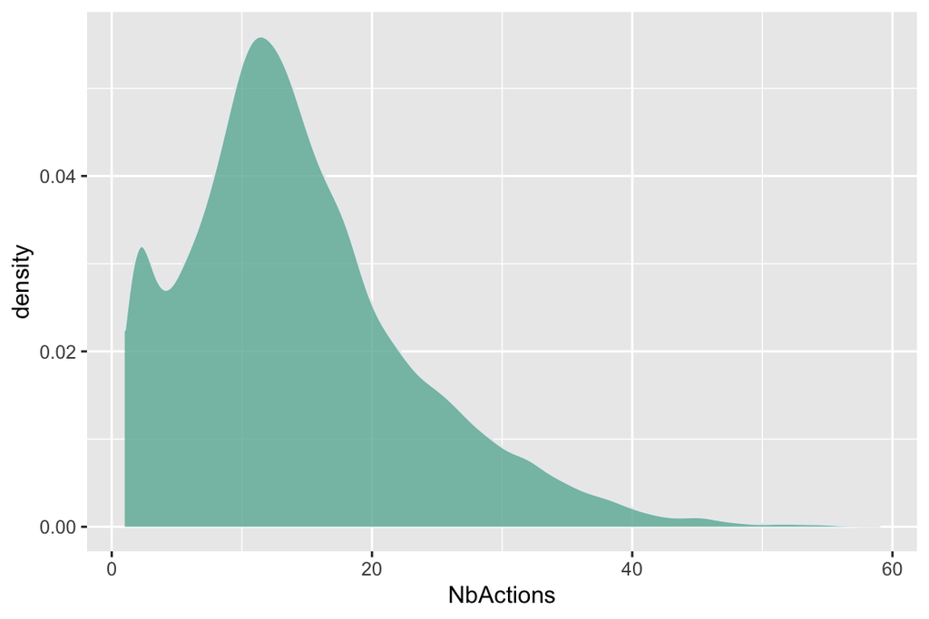

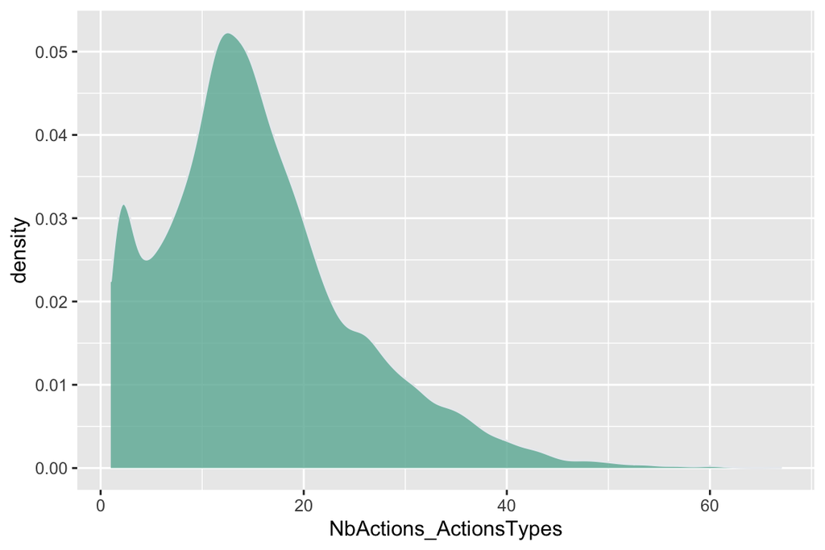

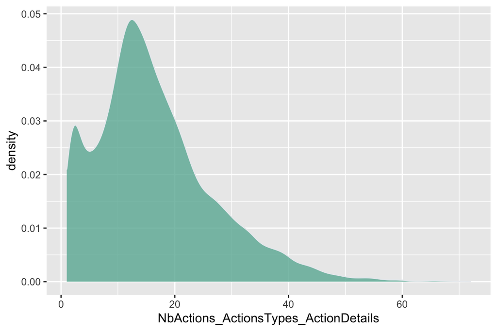

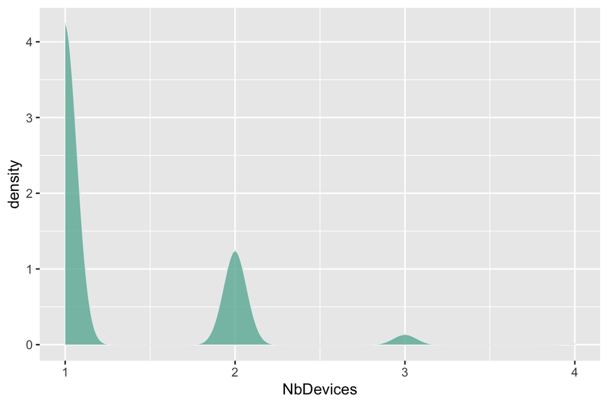

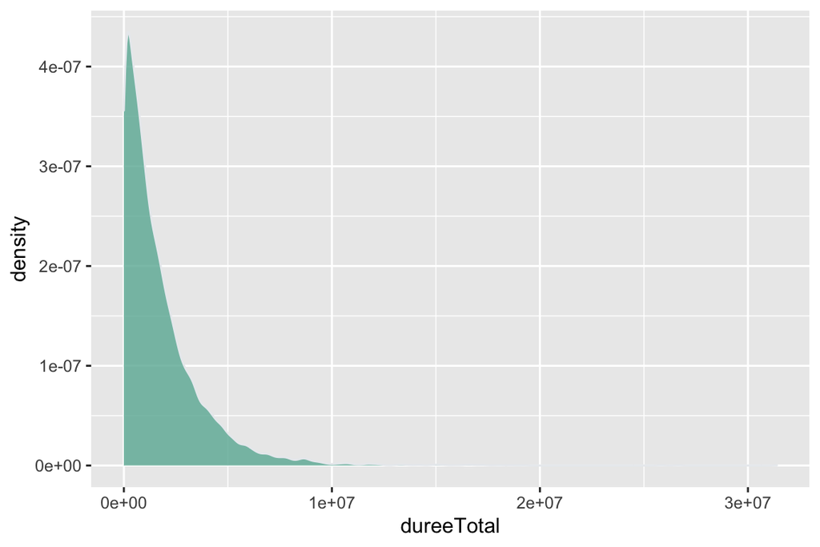

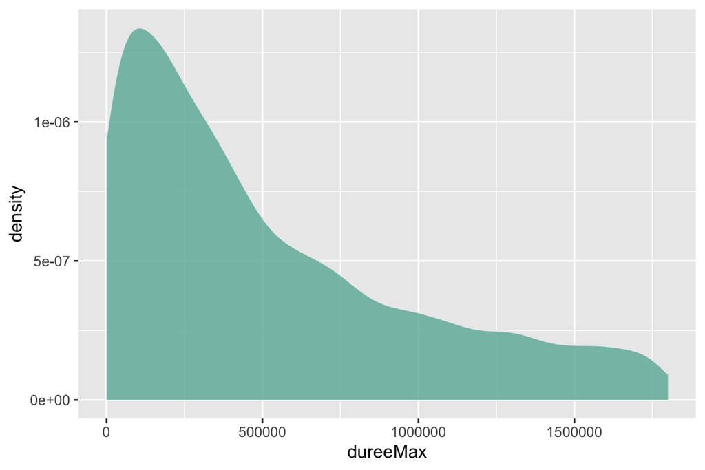

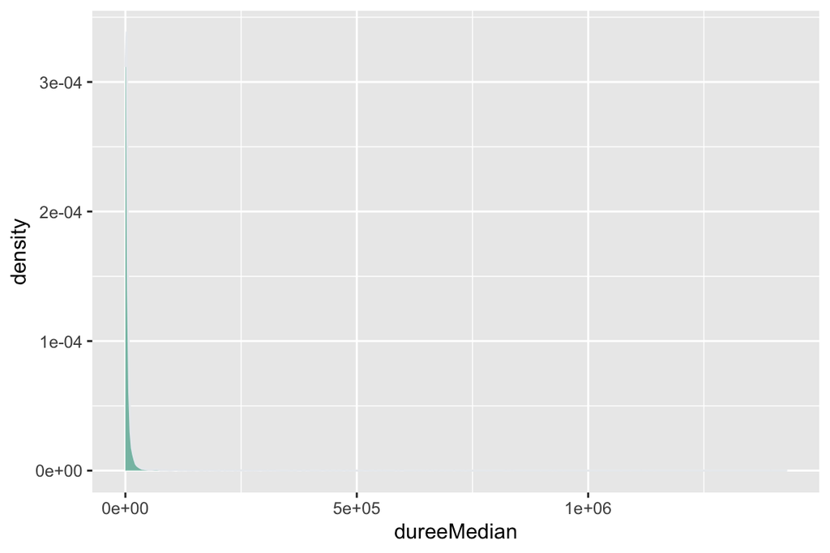

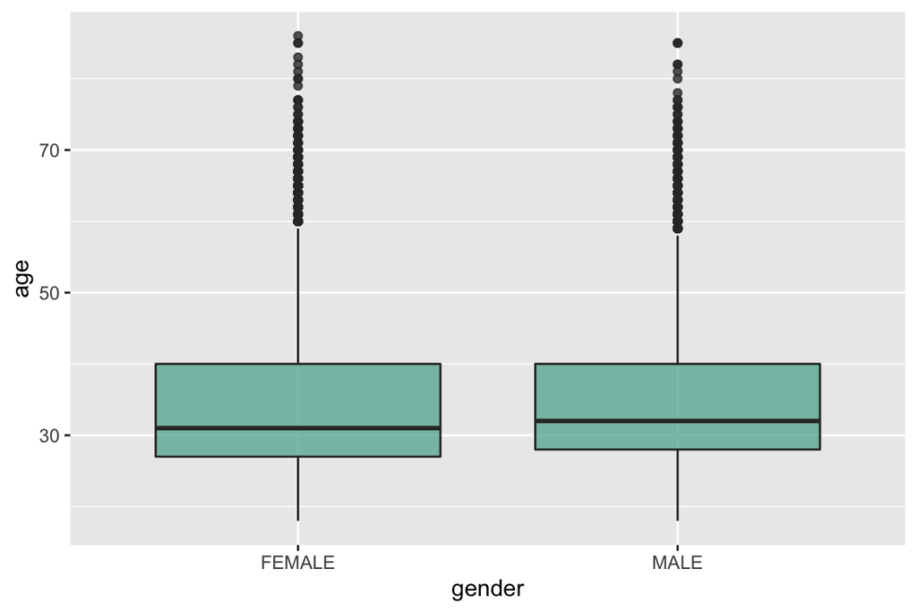

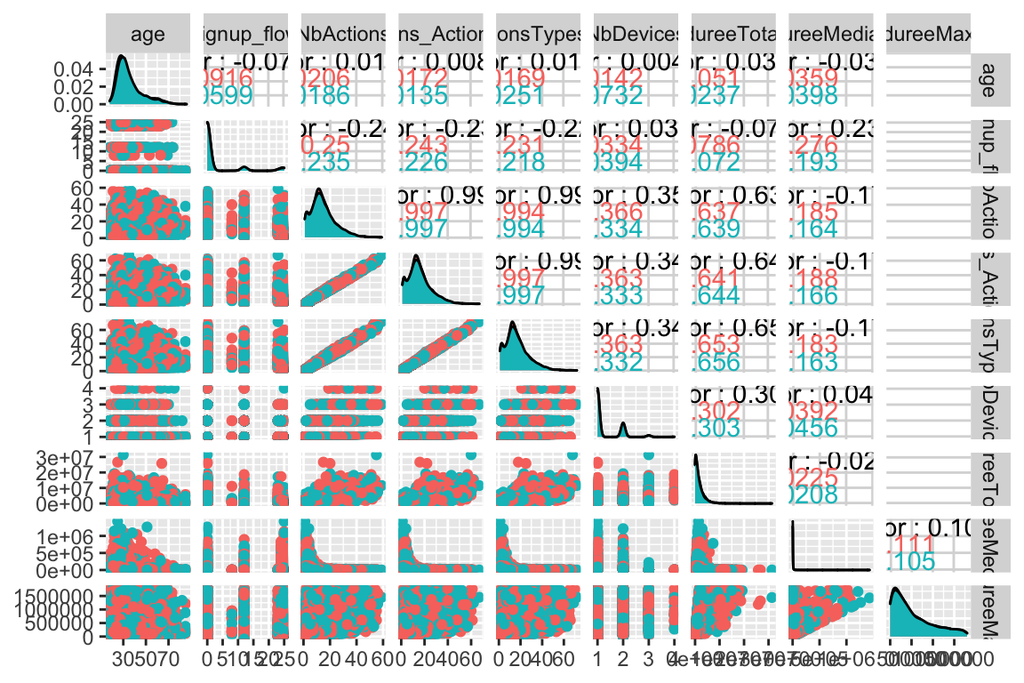

[figure not shown]

```
##
##  Welch Two Sample t-test
##
## data:  train_dataset$age by train_dataset$gender
## t = -1.7841, df = 11439, p-value = 0.07444
## alternative hypothesis: true difference in means is not equal to 0
## 95 percent confidence interval:
##  -0.78366518  0.03685941
## sample estimates:
## mean in group FEMALE   mean in group MALE
##             34.89685             35.27025
```

### Variables Qualitatives

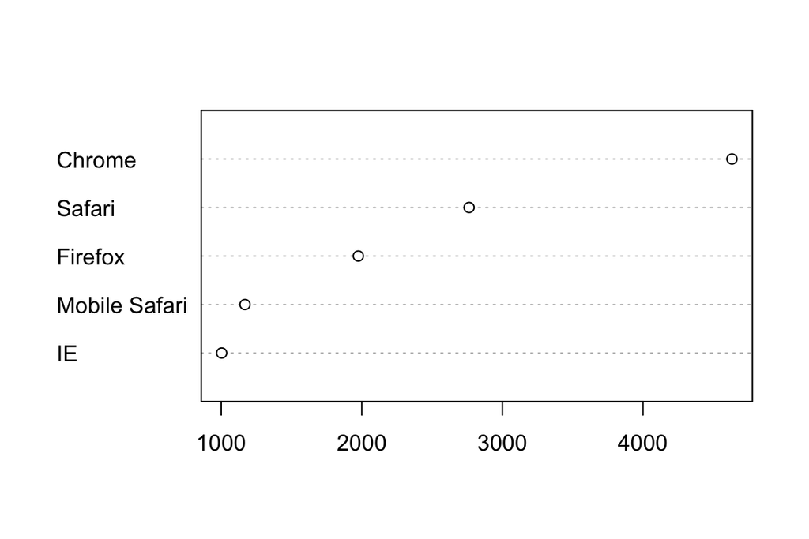

```
##
##         FEMALE MALE
##   AU        28   40
##   CA        68   68
##   DE        39   44
##   ES       148  117
##   FR       298  246
##   GB       163  115
##   IT       228  152
##   NL        47   30
##   other    778  746
##   PT        16   12
##   US      4372 3788
```

```
##
##                   Android App Unknown Phone/Tablet Android Phone Chromebook
##   iPad                                           1             1          0
##   iPhone                                         0             0          0
##   Mac Desktop                                   14             0          1
##   Other/Unknown                                326             1         35
##   Windows Desktop                               12             6          1
##
##                   iPad iPhone iPodtouch Linux Desktop Mac Desktop Tablet
##   iPad             663      9         0             0          34      1
##   iPhone            11    372         1             0          37      0
##   Mac Desktop       21    105         0             0        5273      0
##   Other/Unknown      0      4         0            33           5     67
##   Windows Desktop   31     79         0             2          49      3
##
##                   Windows Desktop
##   iPad                         31
##   iPhone                       26
##   Mac Desktop                  31
##   Other/Unknown                24
##   Windows Desktop            3671
```

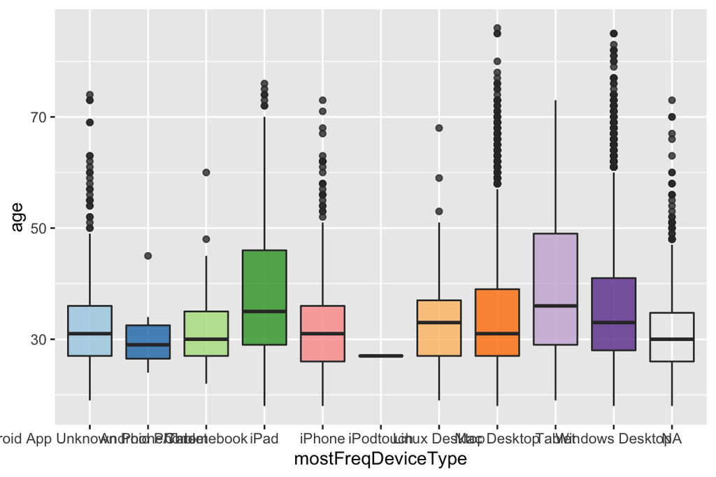

```
##
##  Pearson's Chi-squared test
##
## data:  tab_genre2
## X-squared = 22.159, df = 10, p-value = 0.01431
```

```
##
##         FEMALE  MALE
##   AU     -1.40  1.50
##   CA     -0.57  0.61
##   DE     -0.82  0.88
##   ES      0.50 -0.54
##   FR      0.38 -0.41
##   GB      1.15 -1.24
##   IT      1.71 -1.84
##   NL      0.89 -0.96
##   other  -1.35  1.45
##   PT      0.26 -0.28
##   US      0.00  0.01
```

```
##
##  Pearson's Chi-squared test
##
## data:  tab_device
## X-squared = 34172, df = 36, p-value < 2.2e-16
```

```
##
##                   Android App Unknown Phone/Tablet Android Phone Chromebook
##   iPad                                       -4.67          0.63      -1.58
##   iPhone                                     -3.79         -0.57      -1.23
##   Mac Desktop                               -12.17         -1.99      -4.05
##   Other/Unknown                              77.73          1.06      25.81
##   Windows Desktop                           -10.05          1.91      -3.33
##
##                     iPad iPhone iPodtouch Linux Desktop Mac Desktop Tablet
##   iPad             87.79  -4.74     -0.26         -1.54      -17.29  -1.73
##   iPhone           -3.41  72.48      4.75         -1.19      -12.33  -1.70
##   Mac Desktop     -17.87 -10.55     -0.70         -4.17       50.18  -5.93
##   Other/Unknown    -5.72  -4.27     -0.21         25.02      -15.28  35.66
##   Windows Desktop -14.02  -8.54     -0.59         -2.93      -42.40  -4.39
##
##                   Windows Desktop
##   iPad                     -14.03
##   iPhone                   -10.31
##   Mac Desktop              -42.60
##   Other/Unknown            -11.22
##   Windows Desktop           64.31
```

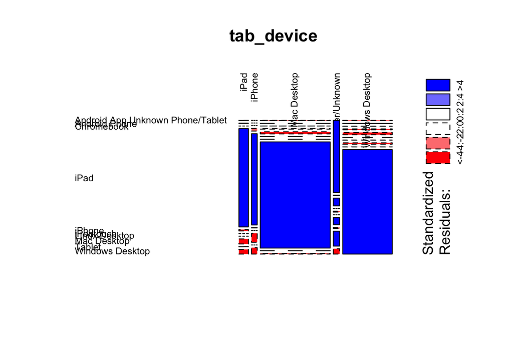

[^1]: amine_aliane@hotmail.fr
[^2]: hammouda.meriam@yahoo.fr
[^3]: imededdine.boussouf@yahoo.com
[^4]: khaoula.elmoutamid@gmail.com
[^5]: lina.saidane96@gmail.com
[^6]: esteban.gobert@me.com